# Solution Exercise 6 - Continuous review policy

Inventory Management

Thomas Kirschstein

# Continuous review with fixed lead time (I)

1. Calculate the cost-optimal order quantity $q$ and re-order level $s$ assuming an order lead time of 1 week and a minimum $\beta$ service level of 97.5%.

We use the algorithm presented in the lecture. In the first iteration we start with $q^0=\sqrt{\frac{2 \cdot 50 \cdot 80}{0.05}} = 400$, $l^0 = 0.025 \cdot 400 = 10$, $s = 40.45$, and $\lambda^0 = 22.64$ as follows:

```
##      iter         q        ef         s    lambda
##   1.00000 400.00000  10.00000  40.45521  22.63507
##      iter         q        ef         s    lambda
##   2.00000 411.16180  10.27905  40.14075  23.07043
##      iter         q        ef         s    lambda
##   3.00000 411.68638  10.29216  40.12603  23.09098
##      iter         q        ef         s    lambda
##   4.00000 411.71136  10.29278  40.12533  23.09195
##      iter         q        ef         s    lambda
##   5.00000 411.71254  10.29281  40.12530  23.09200
```

```
## [1]  40.1253 411.7126
```

2. What happens with the re-order level $s$ if the order lead time reduces to 3 days? (no calculations required)

The reorder level decreases as the expected demand in the lead time decreases. However, $s$ decreases non-linearly as the standard deviation scales by $\sqrt{\frac{3}{5}} > \frac{3}{5}$.

# Continuous review with fixed lead time (II)

A warehouse operator is observing the demand of a particular product. The operator estimates an expected daily demand of 10 and a standard deviation of 5. However, she is not sure which underlying demand distribution is appropriate; a normal distribution or a Gamma distribution are considered as likely candidates. The operator pursues a $(s,q)$ policy for the product which shows a reorder time of 1 day.

Determine the re-order point $s$ for a normal and Gamma distribution of demand assuming that an $\alpha$ or a $\beta$ service level of 99% should by realized. The order quantity is set to $q=80$ units.

For the normal distribution, we have $s^{\alpha} = 10 + 2.3263 \cdot 5 = 21.63$ and $s^{\beta} = 10 + 0.63 \cdot 5 = 13.15$ whereby $L^{-1}(Z,0.16)\approx 0.63$.

For the gamma distribution, we have $s^{\alpha}= 25.2542$ and $s^{\beta} = L^{-1}\left(\Gamma\left(\frac{10^2}{5^2}, \frac{10}{5^2}\right),0.8 \right ) \approx 13.7$.

# Continuous review with stochastic lead time

Assume that the daily demand of cement on a construction side is Gamma distributed. The expected daily demand is estimated to be 8 tons and the standard deviation is supposed to be 6 tons. When new cement is ordered, the lead time varies. Based on historical records, with 20% probability the delivery arrives after 2 days. A delay of 3 days is observed in 50% of all cases and with 30% probability 4 days expire before the shipment arrives.

1. Determine the distributional parameters for all three different lead time realizations.

The distribution parameters for daily demand are $\alpha = \frac{\mu^2}{\sigma^2} = 1.778$ and $\beta =\frac{\mu}{\sigma^2}=0.222$. If the demand is i.i.d., it follows $Y^l \sim \Gamma\left(\sum_{i=1}^l \alpha_i , \beta\right)$

| $l$ | 2 | 3 | 4 |
| --- | --- | --- | --- |
| $\sum_{i=1}^l \alpha_i$ | $3.556$ | $5.333$ | $7.111$ |

Thus, $Y^{l}\sim \Gamma(l\cdot 1.778,0.222)$.

2. Assume an $\alpha$ service level of 99% should be achieved. Which reorder level $s$ should be chosen?

The (probability weighted) demand distributions for all realizations of the lead time as well as joint demand distribution look like

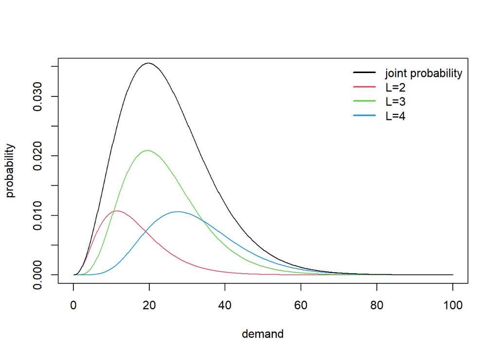

Based on the tables, we estimate $s^\alpha$ for each realization of lead time:

| $l$ | 2 | 3 | 4 |
| --- | --- | --- | --- |
| $P(L=l)$ | $20%$ | $50%$ | $30%$ |
| $s_l^\alpha$ | $42.0$ | $55.9$ | $66.6$ |

We conclude that $s^{\alpha}<s_4^\alpha =66.6$. Furthermore, we have $P(Y^{L=2}>66.6) \approx 0$, $P(Y^{L=3}>66.6) < 0.0015$ and $P(Y^{L=4}>66.6) = 0.01$, we can look for $x$ such that $P(Y^{L=4}>s) = 1-\frac{0.01}{0.3}$ such that $s^{\alpha} \approx 57.3$.